# Reproducible Research: Peer Assessment 1

### Loading and preprocessing the data

```r
# Clear all objects
rm(list=ls())

knitr::opts_chunk$set(fig.path = "PA1_template_files/figure-html/")

if(file.exists("activity.zip")) {
        if(!exists("activityData")){
                activityData <- read.csv(unz("activity.zip","activity.csv"))
        }
}

# Let's prepare the dates for later processing
activityData$date <- as.Date(activityData$date, "%Y-%m-%d")

# Rrebuild the data frame to include days of the week and flagged as weekday or weekend for later processing
activityData <- data.frame(date=activityData$date, weekday=tolower(weekdays(activityData$date)), steps=activityData$steps, interval=activityData$interval)
activityData <- cbind(activityData, daytype=ifelse(activityData$weekday == "saturday" | activityData$weekday == "sunday", "weekend", "weekday"))
activityData <- data.frame(date=activityData$date, weekday=activityData$weekday, daytype=activityData$daytype, interval=activityData$interval, steps=activityData$steps)
```

### What is mean total number of steps taken per day?

- Calculate the total number of steps taken per day

```r
dailySteps <- aggregate(steps ~ date, activityData, sum)
```

- Make a histogram of the total number of steps taken each day

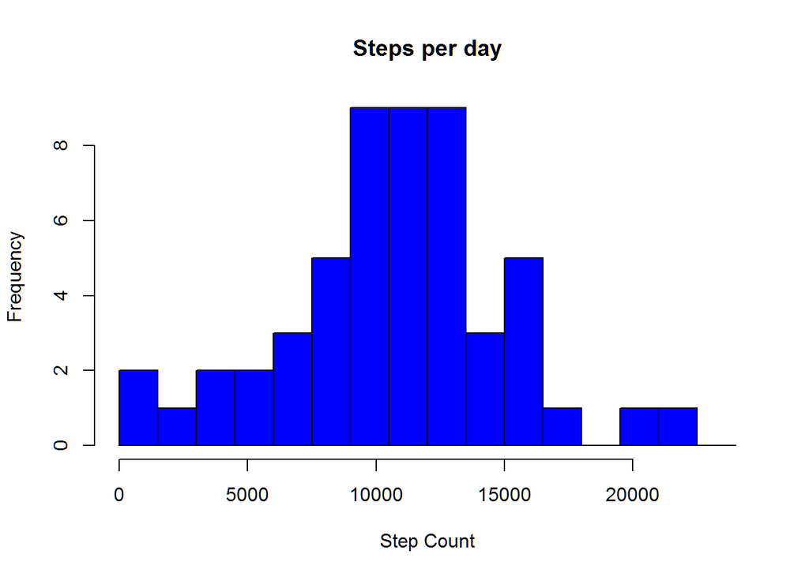

```r
hist(dailySteps$steps, breaks=seq(from=0, to=25000, by=1500), main = paste("Steps per day"), col="blue", xlab="Step Count")
```

```r
meanSteps <- mean(dailySteps$steps)
medianSteps <- median(dailySteps$steps)
```

### What is the average daily activity pattern?

- Make a time series plot (i.e. type = “l”) of the 5-minute interval (x-axis) and the average number of steps taken, averaged across all days (y-axis)

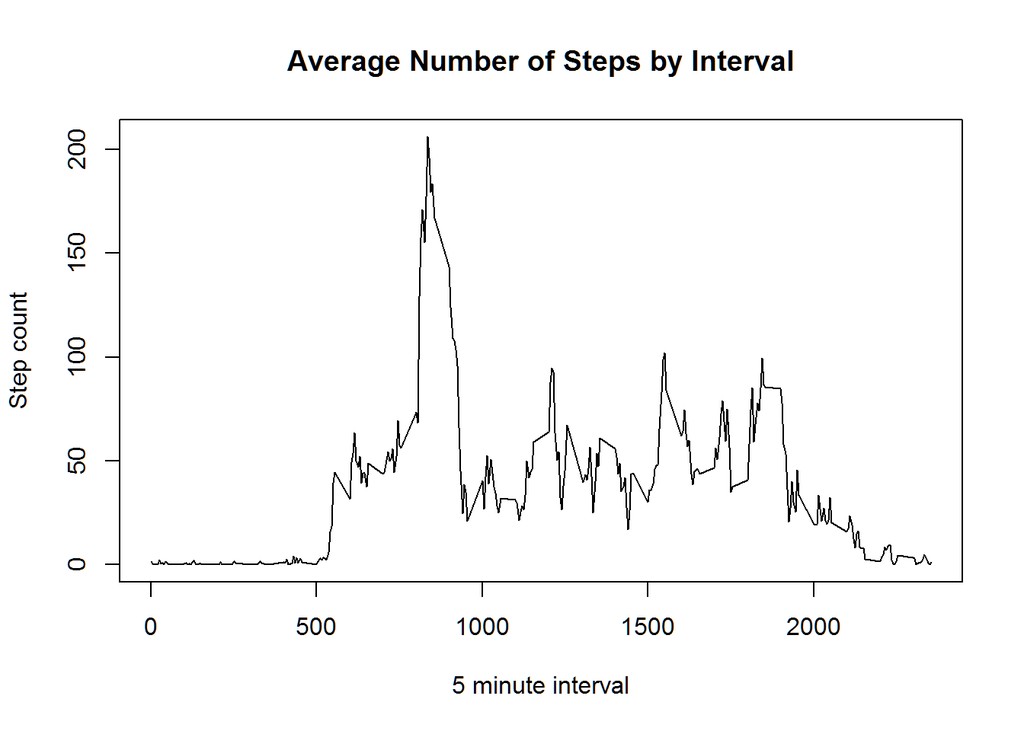

```r
# Calculate average steps for each of 5-minute interval during a 24-hour period
stepsInterval <- aggregate(steps ~ interval, activityData, mean)
plot(stepsInterval$interval,stepsInterval$steps, type="l", xlab="5 minute interval", ylab="Step count",main="Average Number of Steps by Interval")
```

- Which 5-minute interval, on average across all the days in the dataset, contains the maximum number of steps?

```r
maxInterval <- stepsInterval[which.max(stepsInterval$steps),1]
```

The interval with the max number of steps across all days is 835